# TITLE by VISHNU DEVARAKONDA

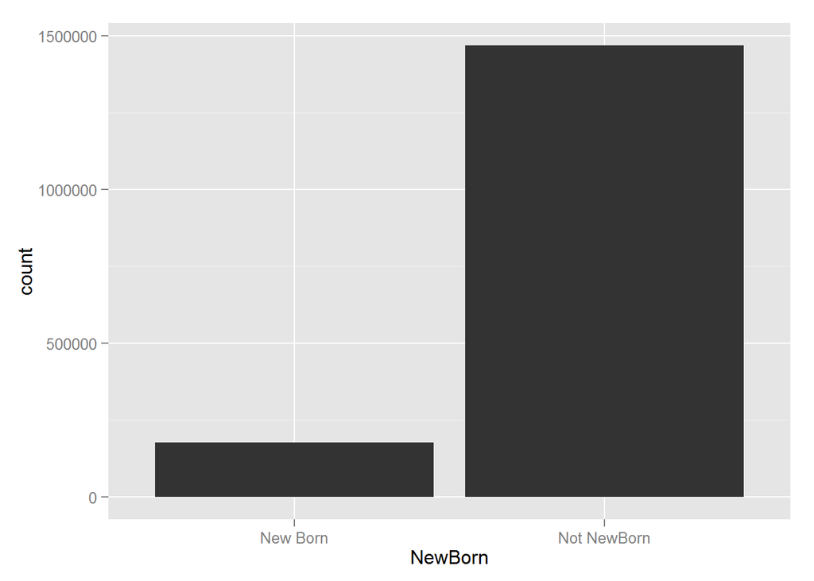

This is something interesting here. We could see that age of patients are less than one year but here we could see that there were more Non-New borns that New borns.

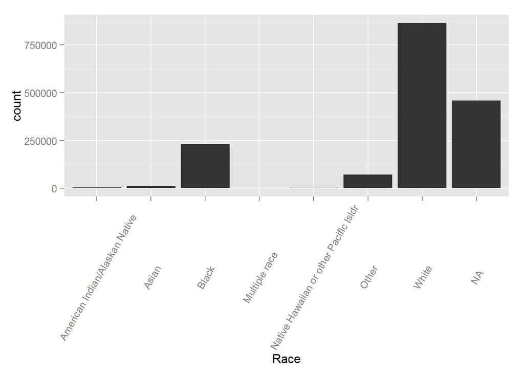

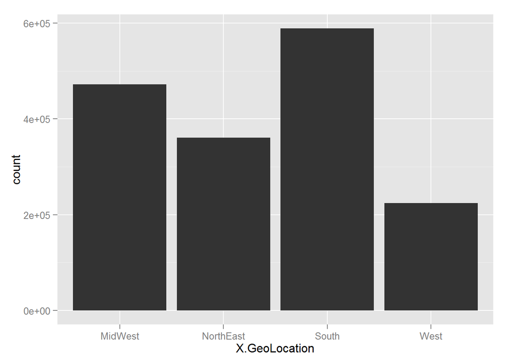

We could see that patients are more in number from Souther Region followed by Mid-West and North-East regions of United States.

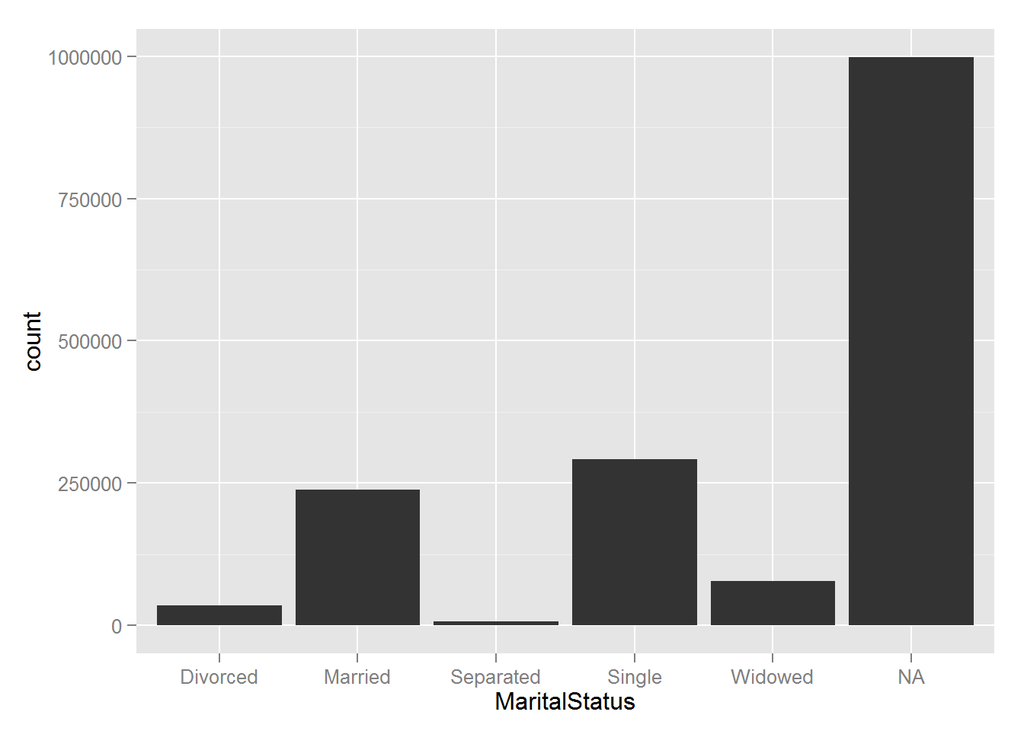

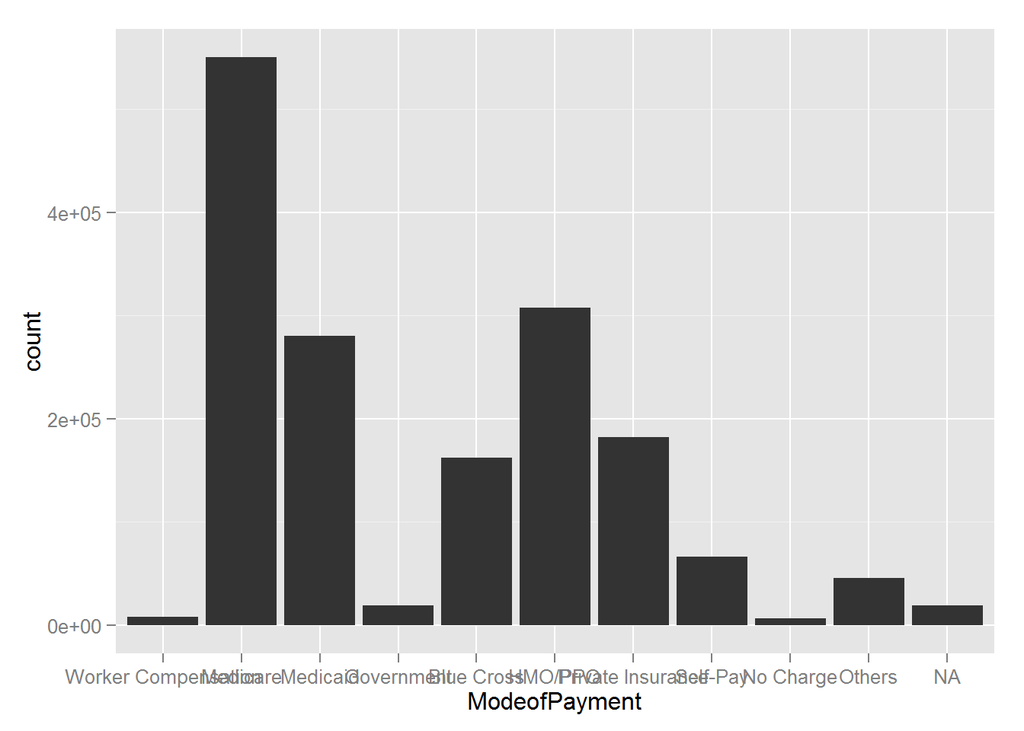

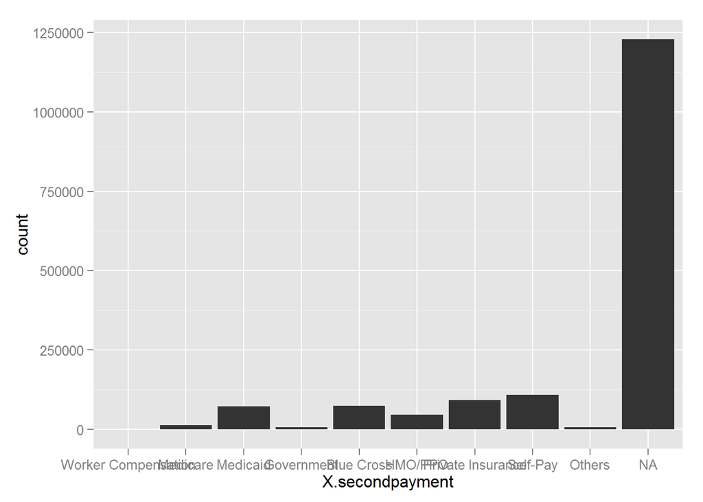

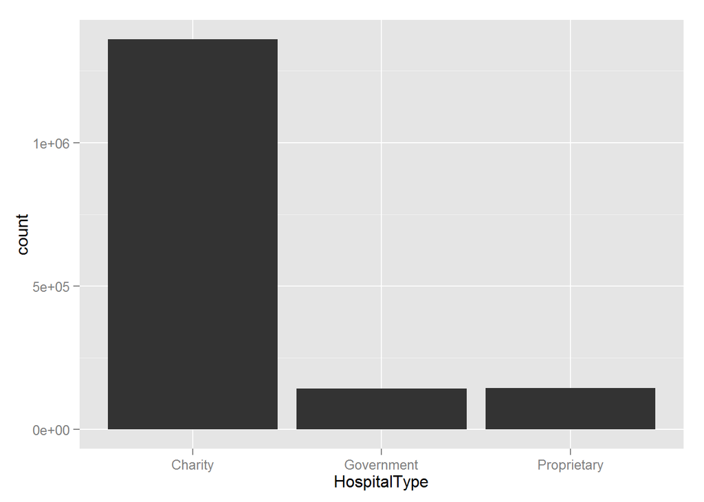

More number of discharges are from Charity hospitals.

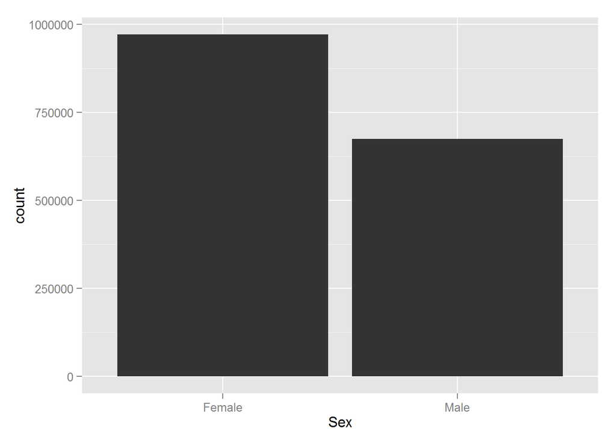

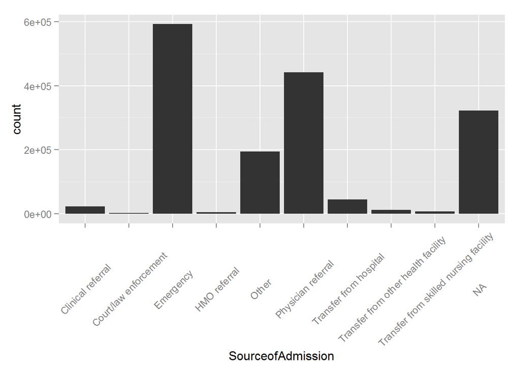

There are more number of Emergency Admissions followed by Physician referrals.

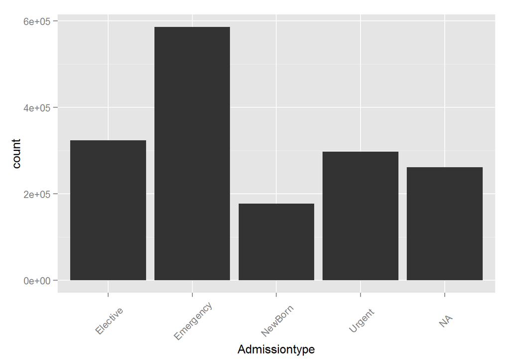

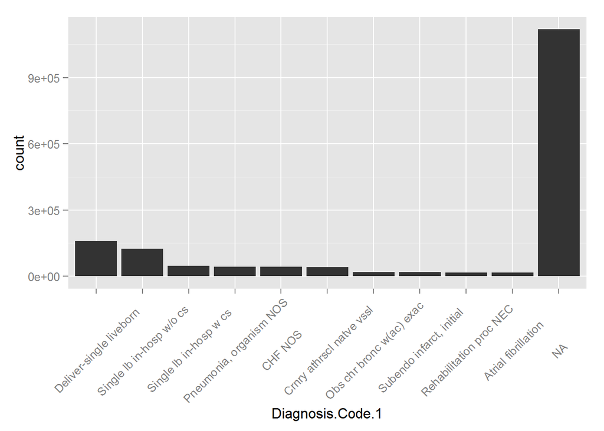

There are more number of Delivery cases but we could see that patients who got discharged are not new borns. This is interesting to explore.

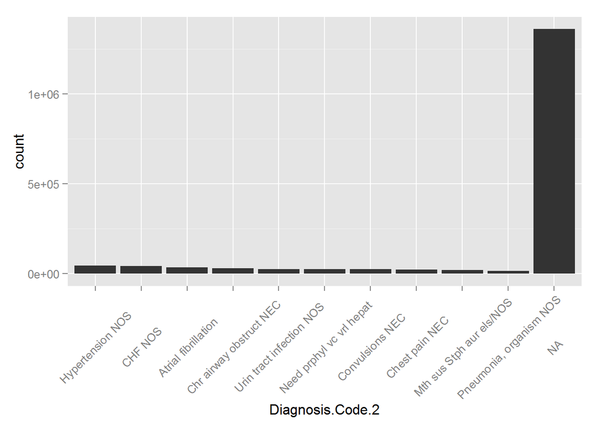

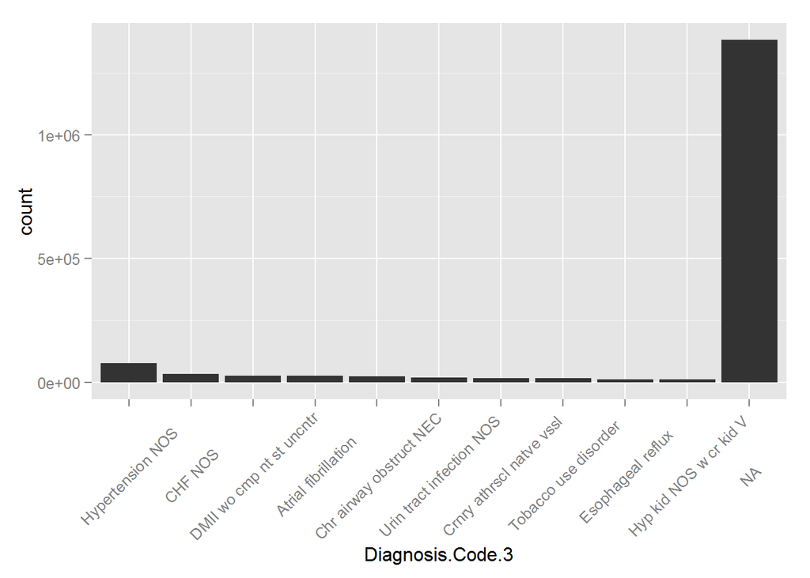

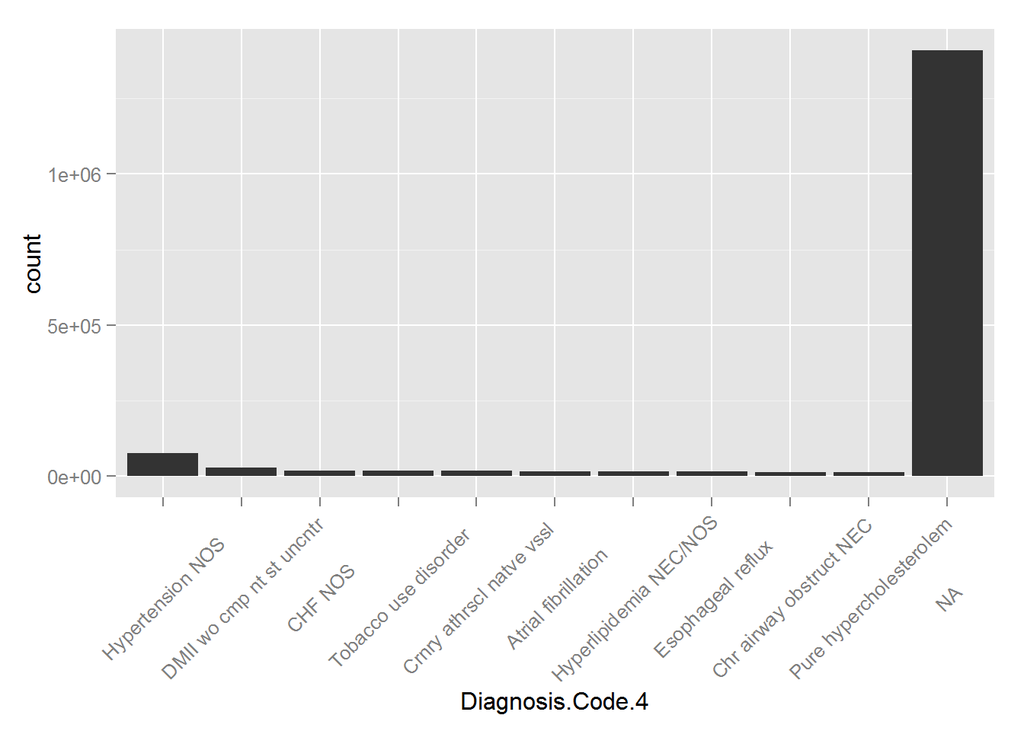

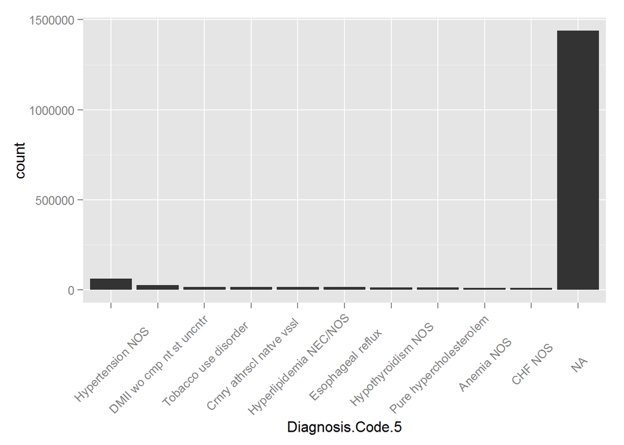

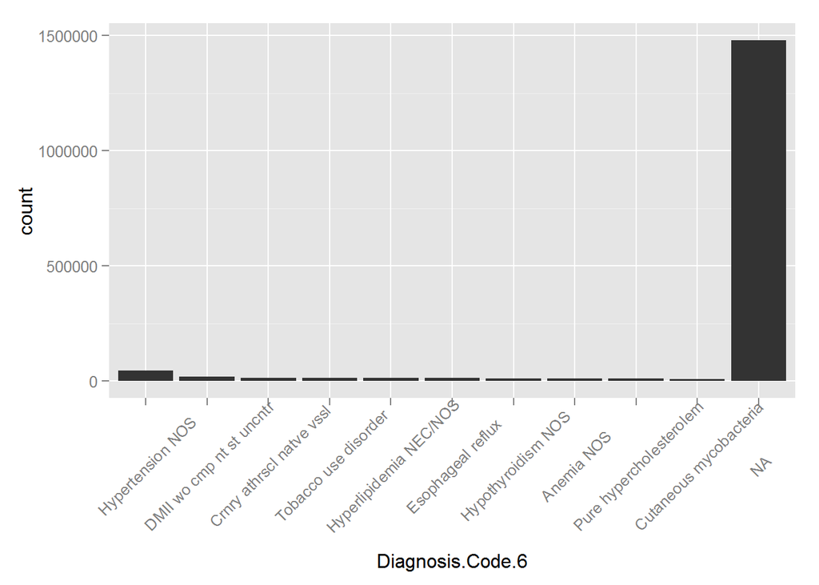

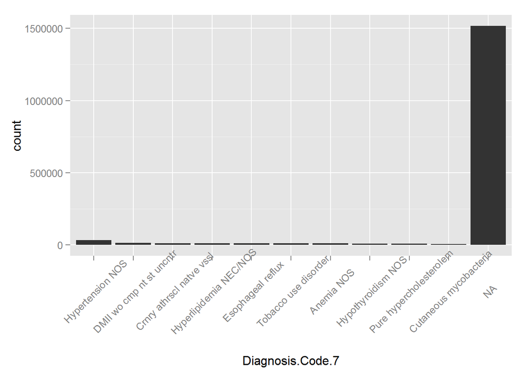

# Univariate Analysis

### What is the structure of your dataset?

There are 1646165 observations in the dataset with 36 features and I have selected omitted 10 features for this analysis. This dataset is mainly about the discharge status of US patients for a period 2001-2005. Their diagnosis, race, payment method etc are some features of interest.

Other Observations:

- New borns are less
- People tend to go to Charity hospitals more
- Whites are more prone to diseases as compared to other Race.
- Apart from NA, Single patients are highest and seperated are lowest.
- Mean of DaysofCare

```
## [1] 4.745727
```

- Mean of Age

```
## [1] 45.76869
```

- Median of DaysofCare

```
## [1] 3
```

- Median of Age

```
## [1] 48
```

- Standard Deviation of DaysofCare

```
## [1] 6.995645
```

- Standard Deviation of Age

```
## [1] 28.37315
```

### What is/are the main feature(s) of interest in your dataset?

The main features in the dataset are Sex, Age, Discharge Status, Diagnosis Code, Source of Admission and Mode of payment.

### What other features in the dataset do you think will help support your investigation into your feature(s) of interest?

Weight, Race and Geolocation are likely to contribute to the discharge status of the patients.

### Did you create any new variables from existing variables in the dataset?

No.I have not created any new variable.

### Of the features you investigated, were there any unusual distributions? Did you perform any operations on the data to tidy, adjust, or change the form of the data? If so, why did you do this?

We could see Age feature is bimodal distrbution. I have done lot of cleaning the data such as removing spaces and blanks, replacing diagnosis codes based on ICD codes, factoring almost all features.

# Bivariate Plots Section

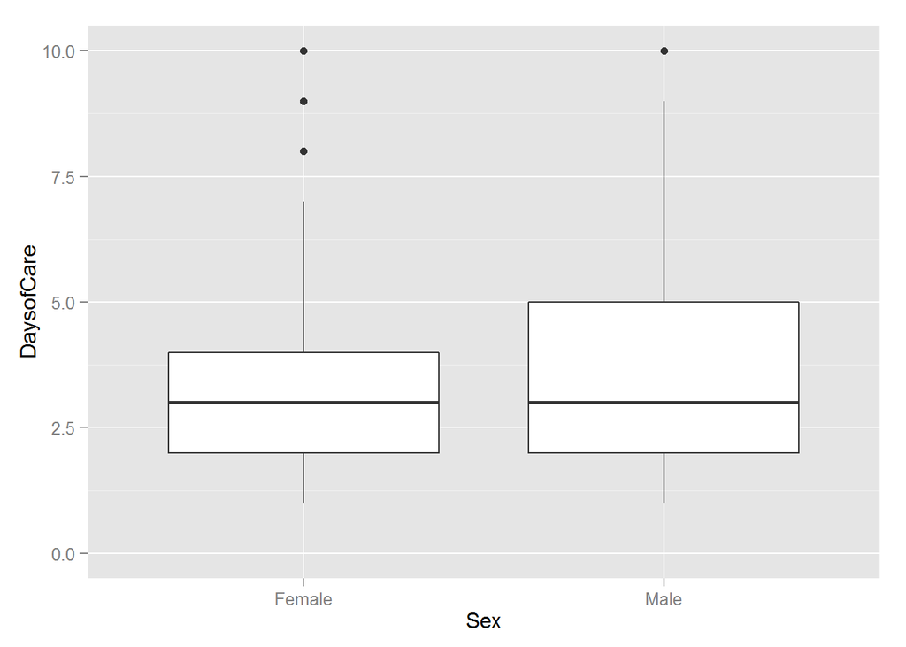

```
## stat_bin: binwidth defaulted to range/30. Use 'binwidth = x' to adjust this.
```

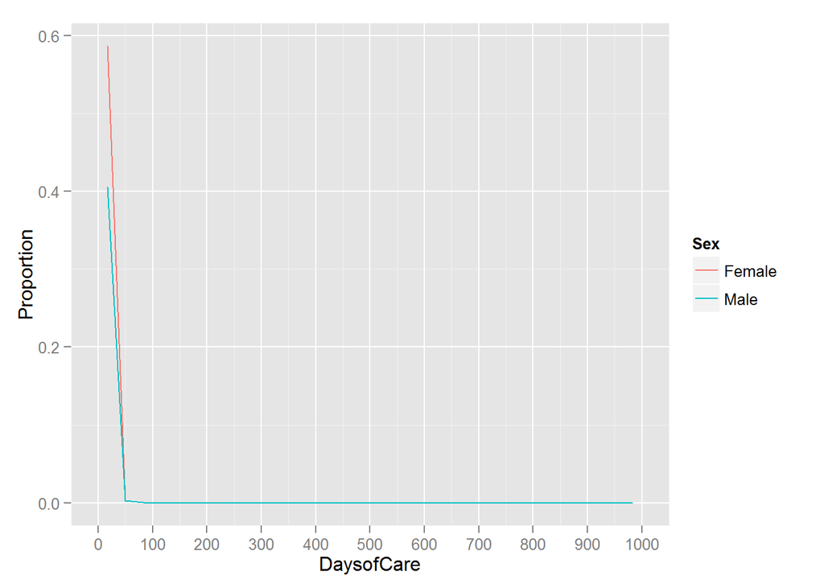

Though females are on higher side of count, males stayed longer than females

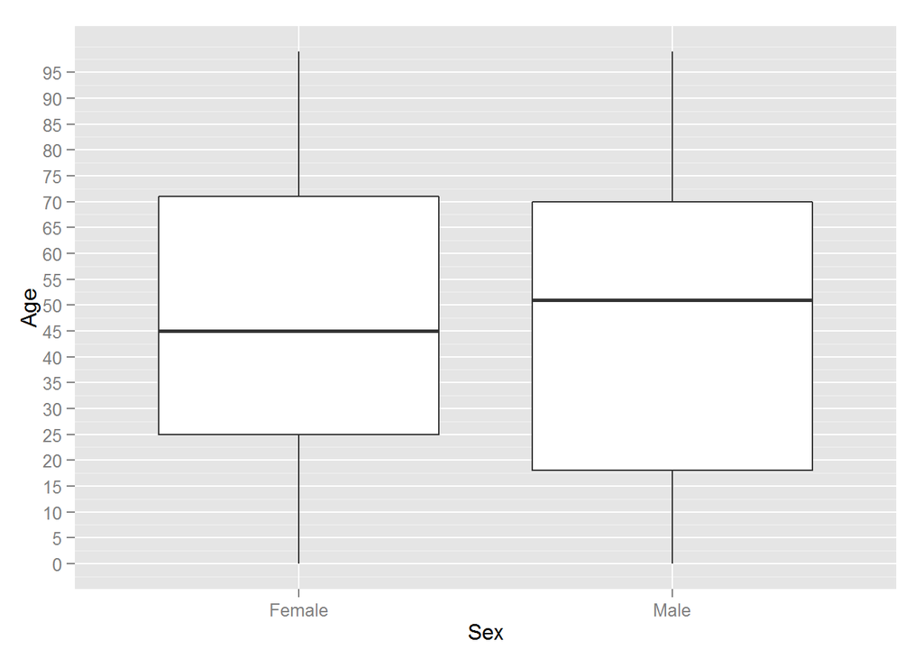

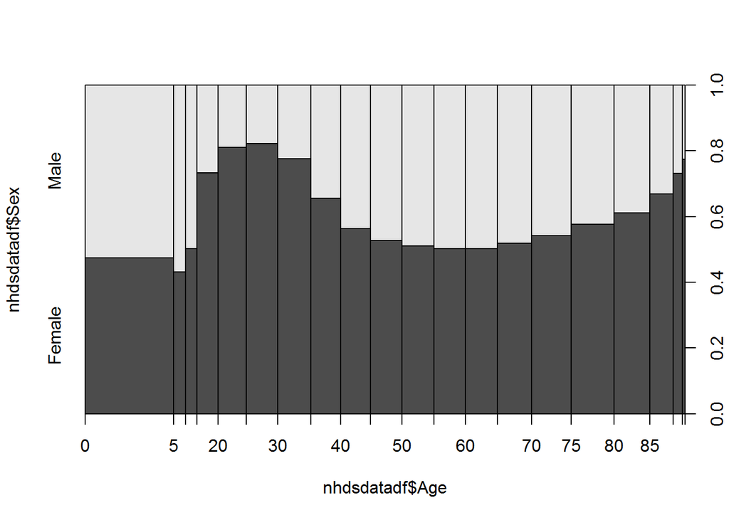

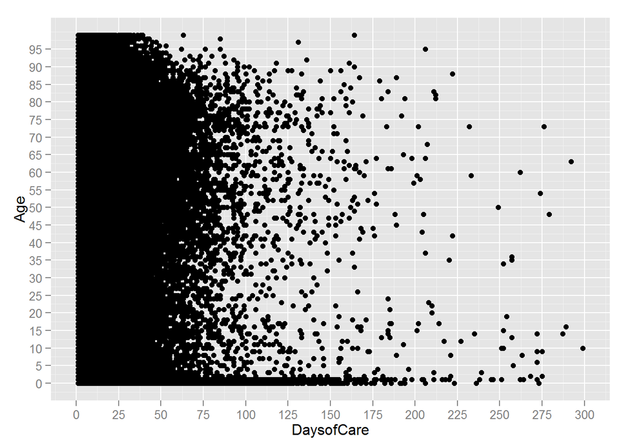

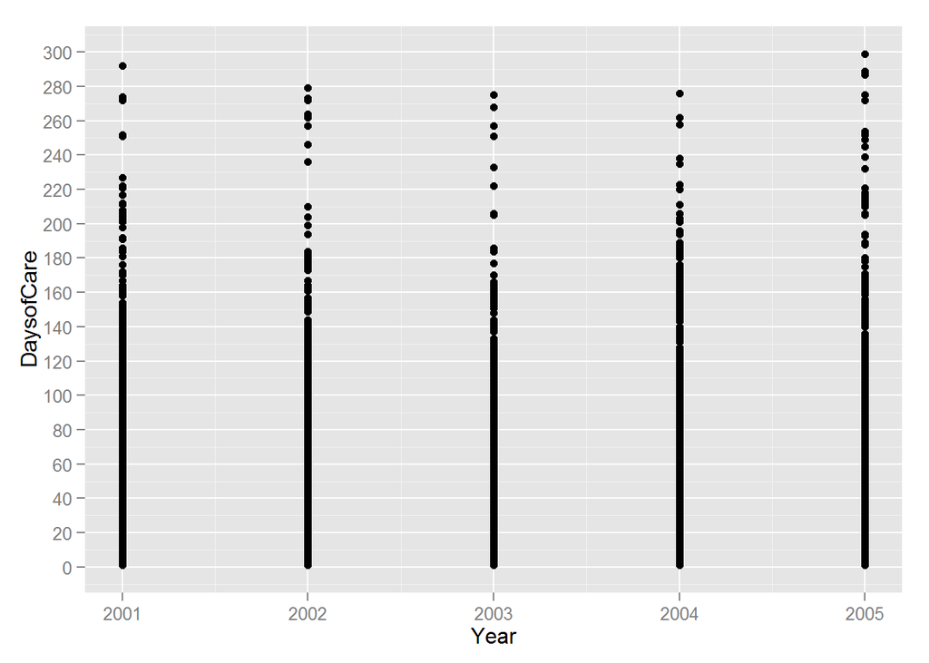

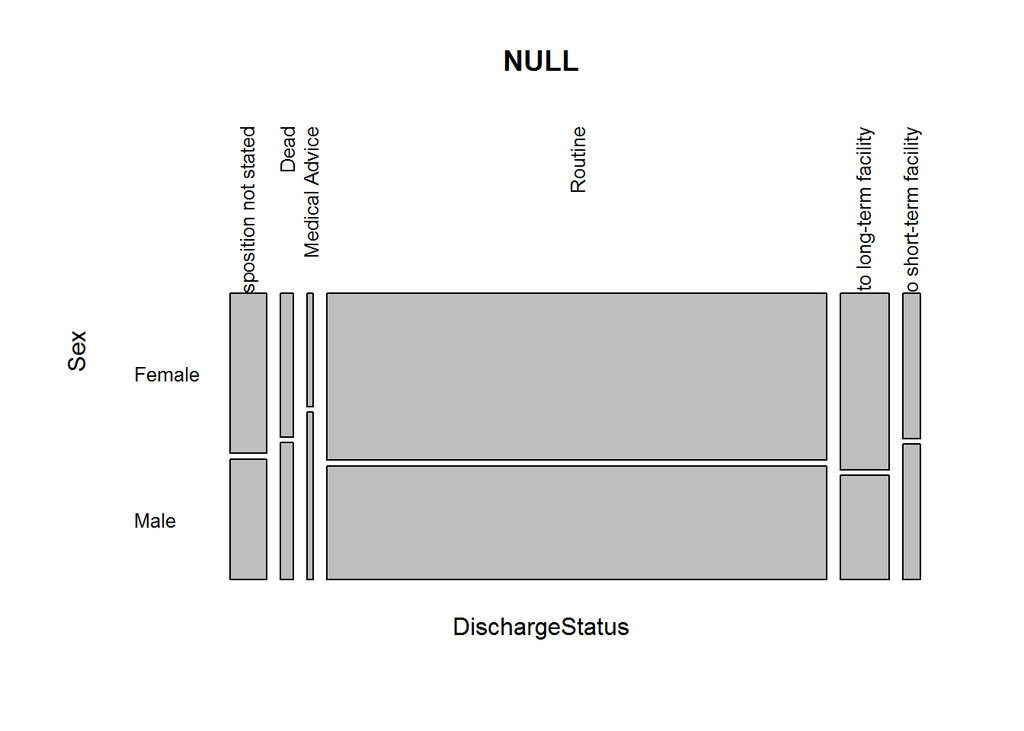

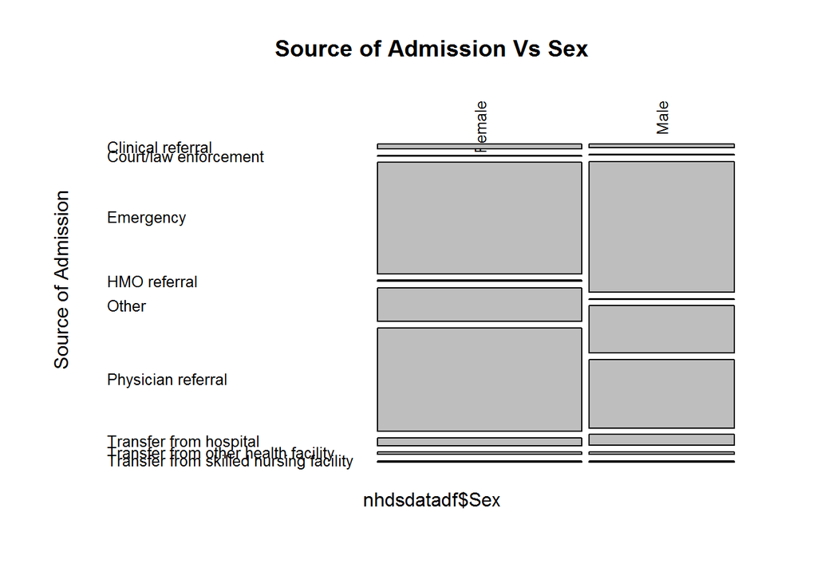

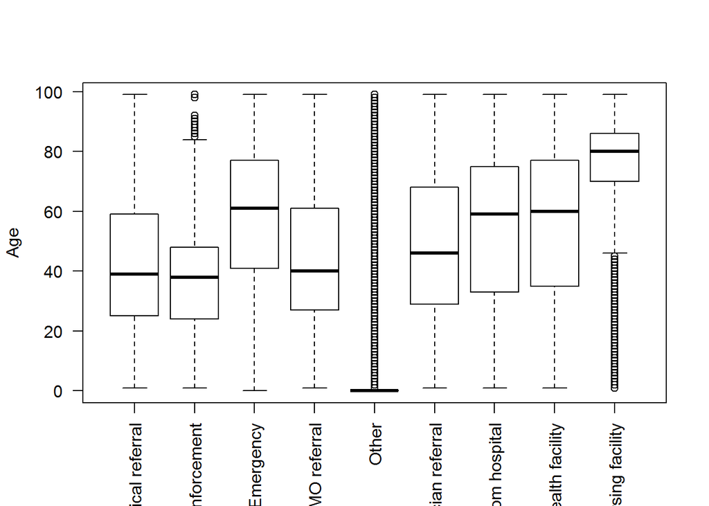

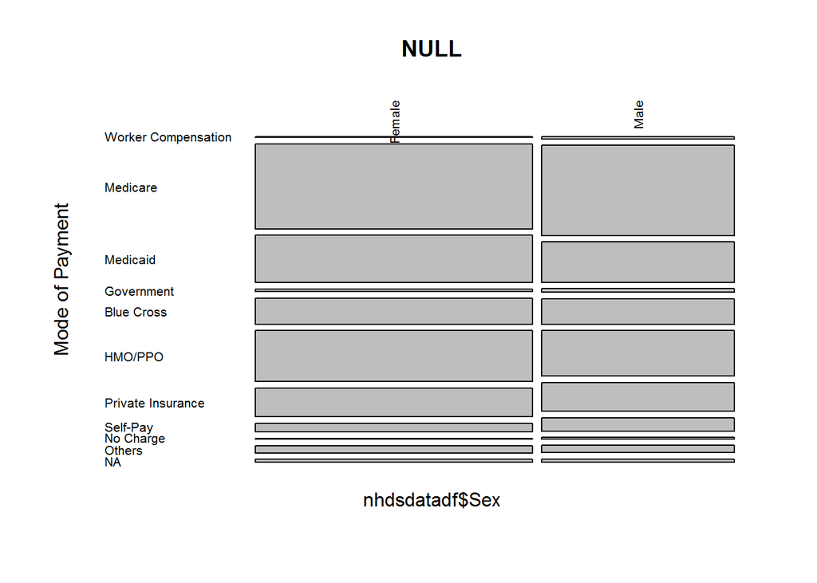

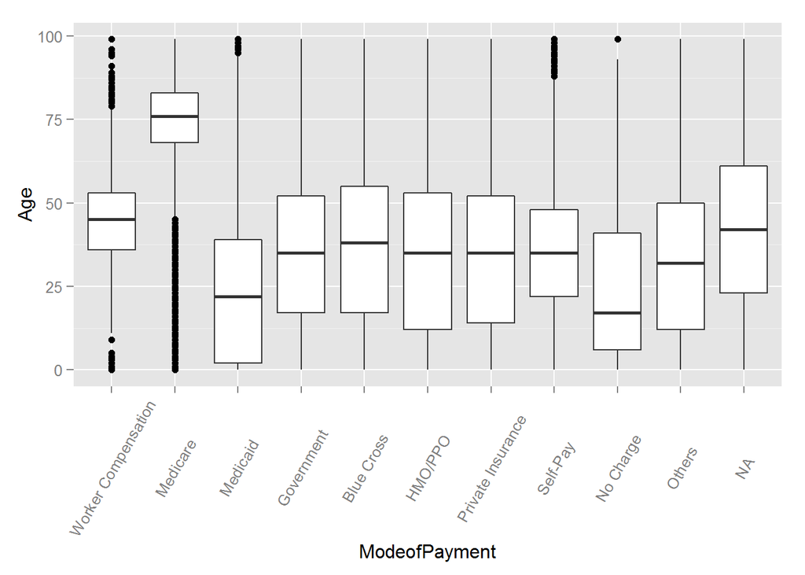